# Análise de Clusters

## Determinar o número óptimo de Clusters

Como iremos utilizar um algoritmo de particionamento onde o número de clusters K é um parâmetro obrigatório, é necessário determinar o valor óptimo para k.

A decisão do número de clusters que melhor representa uma solução é crucial para o resultado final da análise. Embora a discussão de como determinar o número de cluster remonta o trabalho de Thorndike (1953), nenhuma solução satisfatória para o problema foi encontrada até hoje, apenas são sugeridos um conjunto de euristicas e indices, (Donlicar 2002), analisados e comparados por Milligan (1981), Milligan e Cooper (1985).

Seguidamente recorre-se a métodos diretos e estatisticos para determinar um possivel valor de k:

1 - Métodos diretos: Consiste em critérios de optimização, como por exemplo o coeficiente da silhueta ou o método do cotovelo(elbow)  
2 - Métodos de testes estatisticos: Consiste em comparar evidências com a hipotese nula. Por exemplo o método de estatistica GAP.

Os resultado encontrados pela aplicação de diferentes metodos apresentam valores entre 5 e 8 clusters. Iremos testar o algoritmo com K entre 4 e 8 Clusters e selecionar o resultado com melhor coeficiente de silhueta.

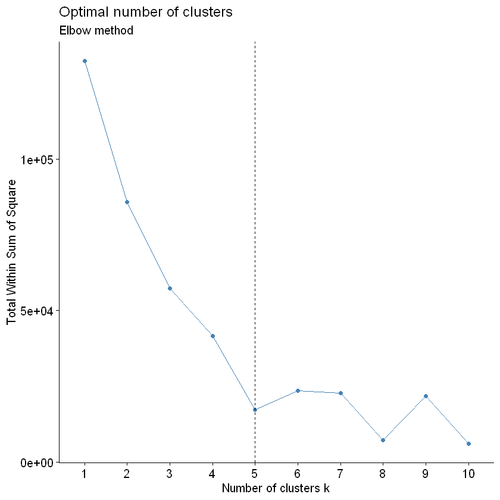

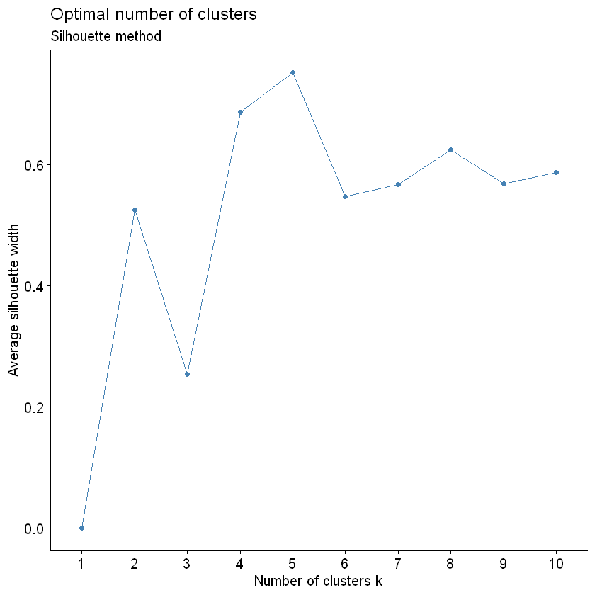

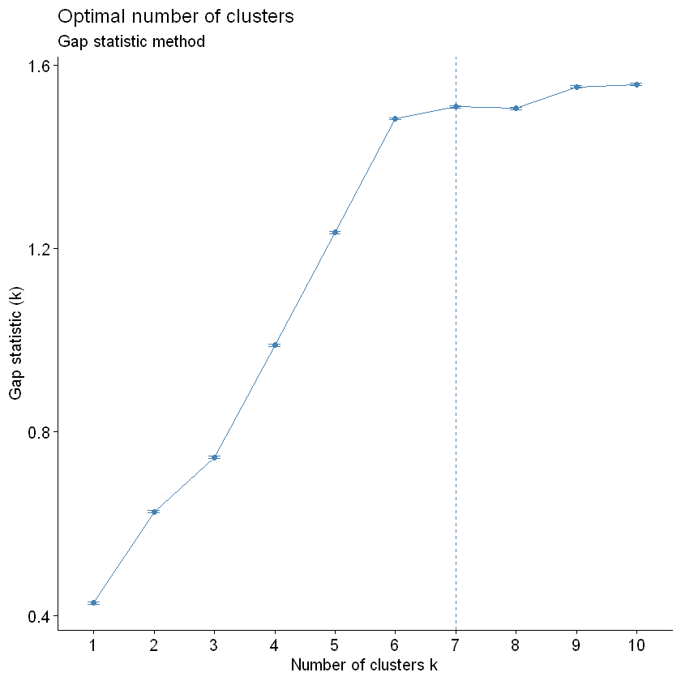

```r
comp1 <- data.frame(pca1$x[,1:4])
#Elbow method
fviz_nbclust(comp1, kmeans, method = "wss") +
  geom_vline(xintercept = 5, linetype = 2)+
  labs(subtitle = "Elbow method")

# Silhouette method
fviz_nbclust(comp1, kmeans, method = "silhouette")+
  labs(subtitle = "Silhouette method")
# Gap statistic
# nboot = 50 to keep the function speedy.
# recommended value: nboot= 500 for your analysis.
# Use verbose = FALSE to hide computing progression.
#set.seed(123)

fviz_nbclust(comp1, kmeans, nstart = 25, method = "gap_stat", nboot = 50)+
  labs(subtitle = "Gap statistic method")

#nb <-NbClust(comp1,distance ="euclidean",min.nc =2,max.nc =10,method ="kmeans")
#fviz_nbclust(nb)+
#labs(subtitle = "Gap statistic method")
```

### Que medidas de distância escolher ?

A escolha da medida de distância é de extrema importância, influenciando o resultado final da análise. È usual, por omissão, os algoritmos utilizarem a distância **Euclidiana e de Manhattan**, mas dependendo dos dados em análise e das questões de investigação podem ser utilizadas outras medidas de dissimiliridade como os **coeficientes de correlação**, descritos como medidas de forma por serem insensíveis às diferenças de magnitude das variáveis envolvidas no cálculo dos coeficientes, (Aldenderfer e Blashfield 1984; Kassambara 2017).

Uma vez que pretendemos agrupar os objetos de acordo com a magnitude da pontuação das respostas do questionário, foram consideradas as distâncias Euclideanas e de Manhattan.

Foram testados valores de K=4,5,6,7 e 8.

k=6 apresenta o melhor coeficiente de silhueta, 0,8 .

```
  cluster size ave.sil.width
1       1   25          0.61
2       2    5          0.82
3       3    5          0.73
4       4   13          0.72
```

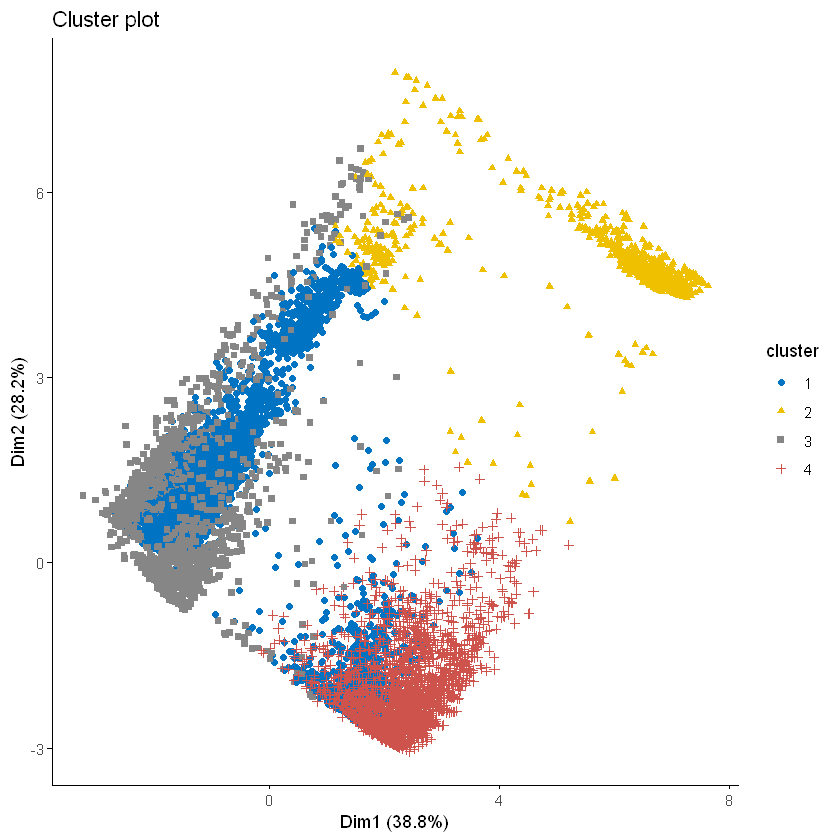

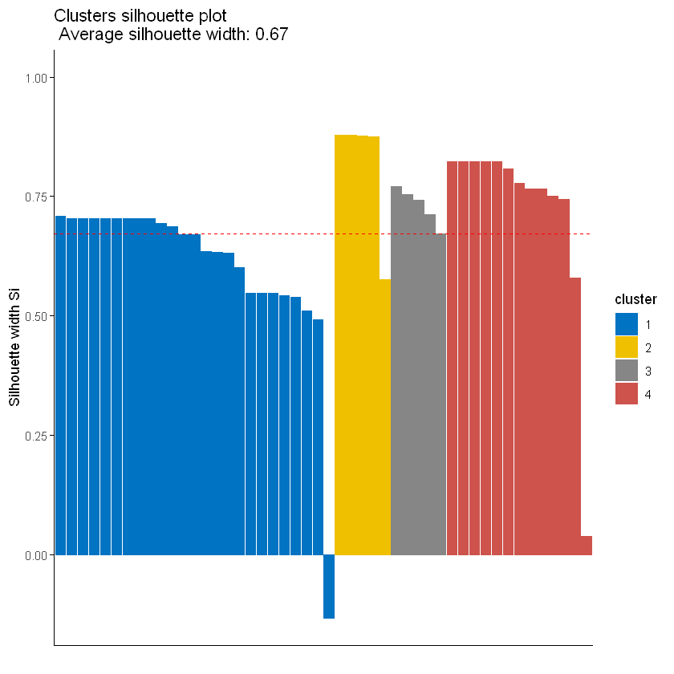

```
  cluster size ave.sil.width
1       1   25          0.61
2       2    6          0.82
3       3    6          0.73
4       4    5          0.70
5       5    8          0.72
```

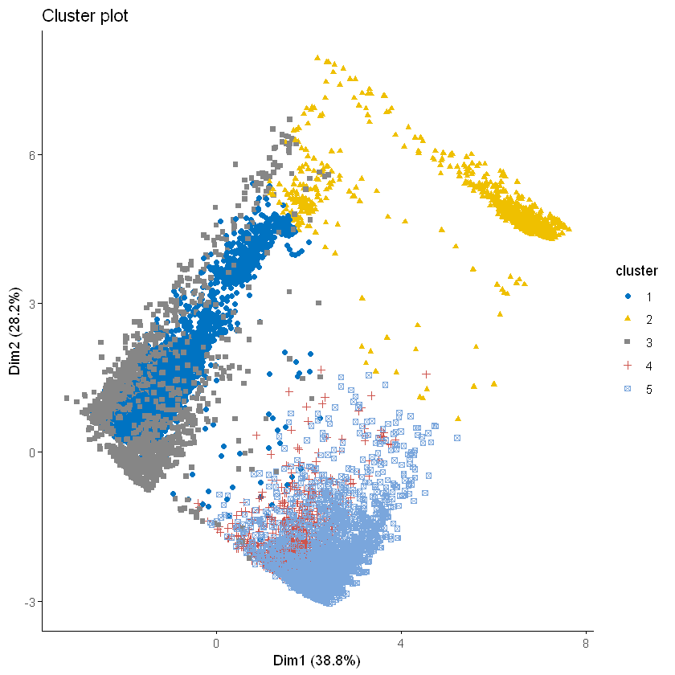

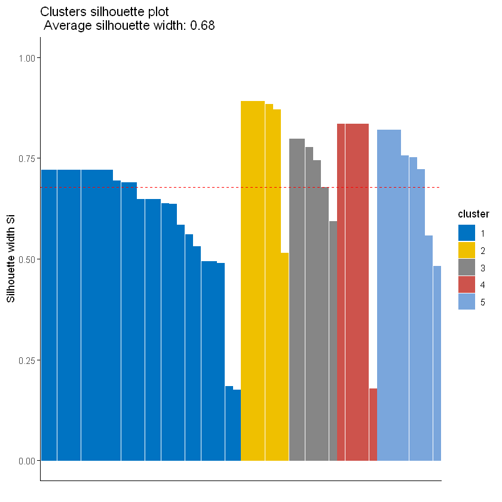

```
  cluster size ave.sil.width
1       1   26          0.79
2       2    7          0.65
3       3    4          0.92
4       4    2          0.97
5       5    2          1.00
6       6   11          0.88
```

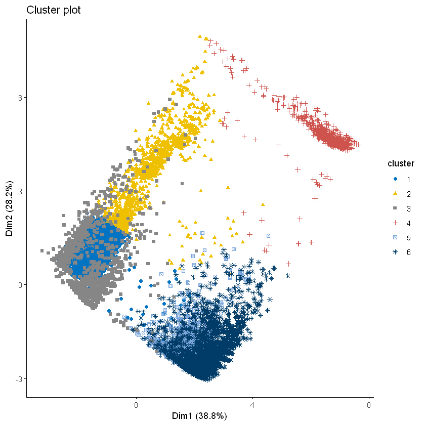

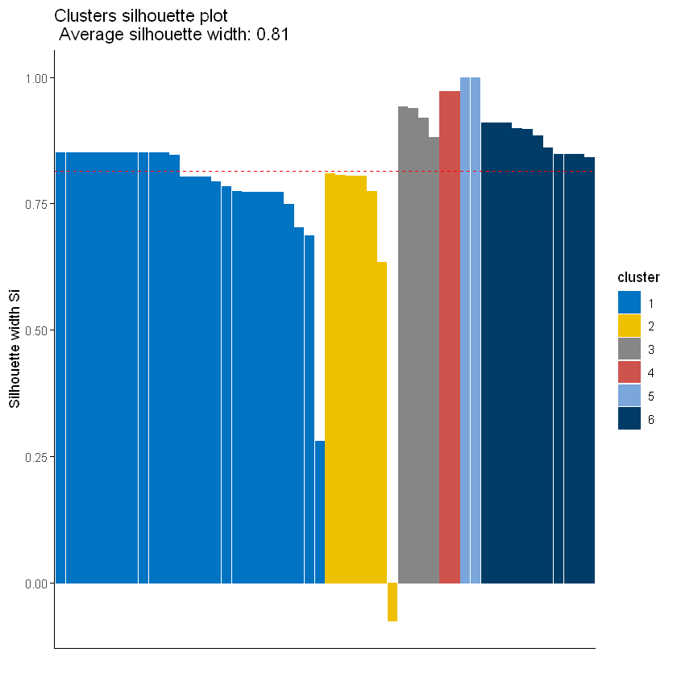

```
  cluster size ave.sil.width
1       1    8          0.63
2       2    5          0.61
3       3    9          0.70
4       4   20          0.49
5       5    2          1.00
6       6    4          0.59
7       7    6          0.78
```

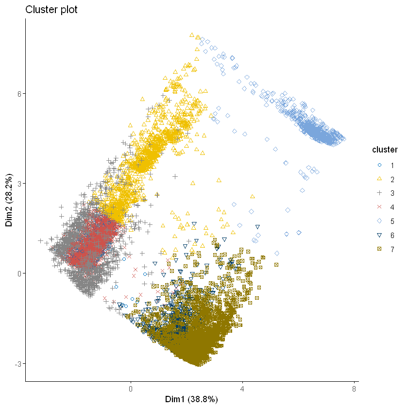

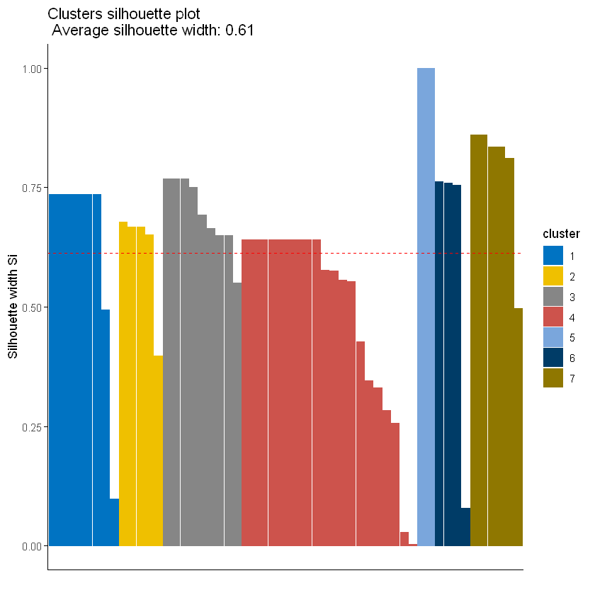

```
  cluster size ave.sil.width
1       1    6          0.63
2       2    2          0.63
3       3    3          0.80
4       4   15          0.61
5       5    3          0.81
6       6    5          0.85
7       7   15          0.84
8       8    7          0.55
```

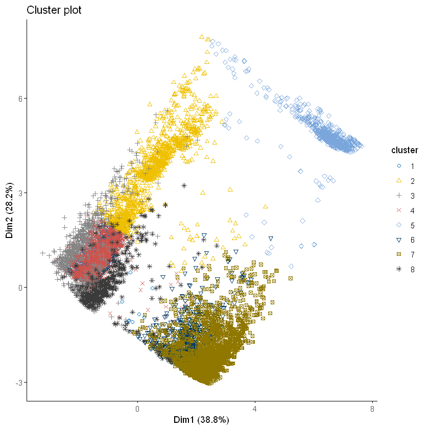

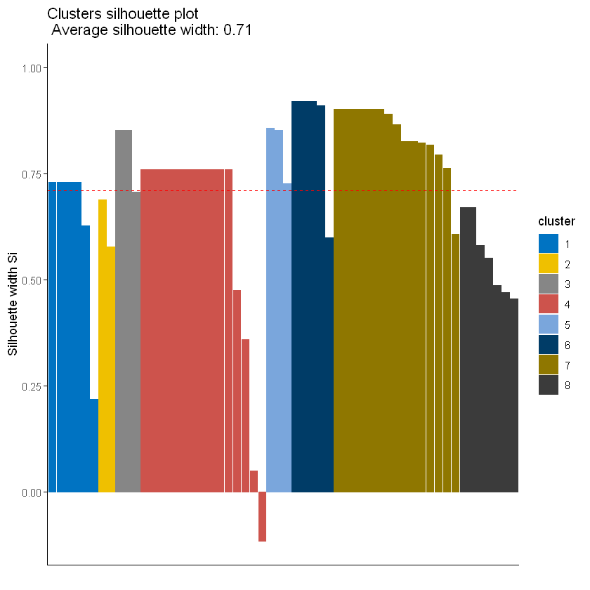

```r
clara.res_k4 <- clara(comp, 4, samples = 50, pamLike = TRUE, metric='euclidean')
fviz_cluster(clara.res_k4, data = comp, stand = FALSE,
             ellipse = FALSE, show.clust.cent = FALSE,
             geom = "point",palette = "jco", ggtheme = theme_classic())
fviz_silhouette(clara.res_k4, palette = "jco", ggtheme = theme_classic())

clara.res_k5 <- clara(comp, 5, samples = 50, pamLike = TRUE, metric='euclidean')
fviz_cluster(clara.res_k5, data = comp, stand = FALSE,
             ellipse = FALSE, show.clust.cent = FALSE,
             geom = "point",palette = "jco", ggtheme = theme_classic())
fviz_silhouette(clara.res_k5, palette = "jco", ggtheme = theme_classic())


clara.res <- clara(comp, 6, samples = 50, pamLike = TRUE,metric='euclidean')
fviz_cluster(clara.res, data = comp, stand = FALSE,
             ellipse = FALSE, show.clust.cent = FALSE,
             geom = "point",palette = "jco", ggtheme = theme_classic())
fviz_silhouette(clara.res, palette = "jco", ggtheme = theme_classic())


clara.res_k7 <- clara(comp, 7, samples = 50, pamLike = TRUE,metric='euclidean')
fviz_cluster(clara.res_k7, data = comp, stand = FALSE,
             ellipse = FALSE, show.clust.cent = FALSE,
             geom = "point",palette = "jco", ggtheme = theme_classic())
fviz_silhouette(clara.res_k7, palette = "jco", ggtheme = theme_classic())


clara.res_k8 <- clara(comp, 8, samples = 50, pamLike = TRUE,metric='euclidean')
fviz_cluster(clara.res_k8, data = comp, stand = FALSE,
             ellipse = FALSE, show.clust.cent = FALSE,
             geom = "point",palette = "jco", ggtheme = theme_classic())
fviz_silhouette(clara.res_k8, palette = "jco", ggtheme = theme_classic())
```

## Interpretação dos Clusters obtidos para K=6

### Análise em termos dos centróides

Dos gráficos abaixo podemos concluir o seguinte:

**O Grupo 1** é o que mais valoriza aspetos relacionados com a cortesia do condutor, tipo de condução e pontualidade na partida.

**O Grupo 3** é o que menos valoriza aspetos relacionados com a cortesia do condutor, tipo de condução e pontualidade na partida

**O Grupo 4** é o que mais valoriza aspetos relacionados com a limpeza interior e exterior do veiculo, simpatia do contudor e pontualidade na chegada.

**O Grupo 6** é o que mais valoriza aspetos relacionados com o conforto a bordo, como o acesso a wifi.

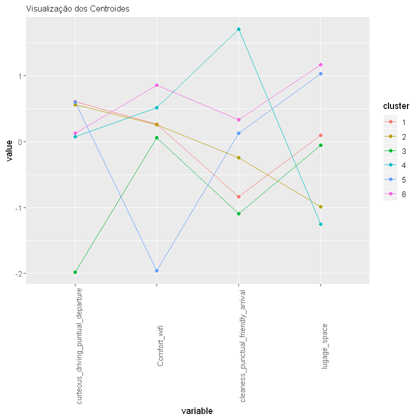

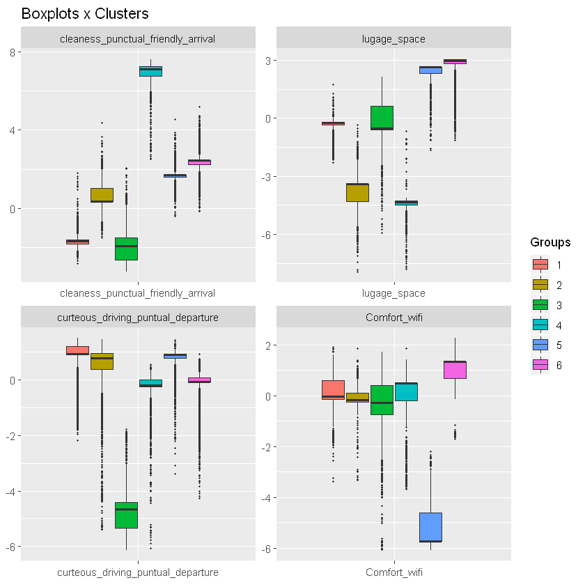

```r
#clust.grps(comp, clara.res$clustering,parcoord=T, suppress=T)
cluster <- as.factor(unique(clara.res$cluster))
medoids <- as.data.frame(clara.res$medoids)

medoids<-cbind(medoids, cluster)
ggparcoord(medoids,columns = 1:(length(names(medoids))-1), groupColumn = length(names(medoids)),order = "anyClass",
    showPoints = TRUE,
    title = "Visualização dos Centroides",
    alphaLines = 1)+
  theme(
    plot.title = element_text(size=10)
  )+
  theme(axis.text.x = element_text(angle = 90))

######
ToCluster.c<-cbind(comp, clara.res$cluster)
colnames(ToCluster.c)[length(names(comp))+1]<-c("Group")

df.m <- melt(ToCluster.c, id.var = "Group")
df.m$Group <- as.character(df.m$Group)

p <- ggplot(data = df.m, aes(x=variable, y=value)) +
  geom_boxplot(aes(fill = Group),outlier.size = 0.5) +
  facet_wrap( ~ variable, scales="free", ncol = 2) +
  xlab(label = NULL) + ylab(label = NULL) + ggtitle("Boxplots x Clusters") +
  guides(fill=guide_legend(title="Groups"))

p
```

## Fazemos persisitr os clusters obtidos na base de dados Sql para futura exploração analitica e tomada de decisão pela YFT.

```r
feedback_cluster <-cbind(feedback,cluster=as.factor(clara.res$cluster))

df_to_save <- data.frame(feedback_cluster$book_id,feedback_cluster$codigo, feedback_cluster$cluster)

names(df_to_save) <- c("book_id", "codigo", "cluster")

sqlSave(conn, df_to_save, tablename = "feedback_cluster", rownames=FALSE, append=TRUE)
```

## Análise Exploratória das principais características dos clientes de cada cluster

```r
Cluster_Analitics <- sqlQuery(conn, "select a.cluster, b.* from feedback_cluster a
inner join FeatureEngineering b on a.book_id=b.book_id
where aeroporto_origem is not null
")
```

```r
#data<-cbind(data, countrycode(data$country, origin = 'country.name', destination="region"))
Cluster_Analitics<-cbind(Cluster_Analitics, countrycode(Cluster_Analitics$country, origin = 'country.name', destination="region"))
colnames(Cluster_Analitics)[length(Cluster_Analitics)]<-c("Region")
```

```r
skim(Cluster_Analitics)
```

```
-- Data Summary ------------------------
                           Values
Name                       Cluster_Analitics
Number of rows             60113
Number of columns          48
_______________________
Column type frequency:
  factor                   11
  numeric                  33
  POSIXct                  4
________________________
Group variables            None

-- Variable type: factor -------------------------------------------------------
# A tibble: 11 x 6
```

[output cut: 114 more lines]

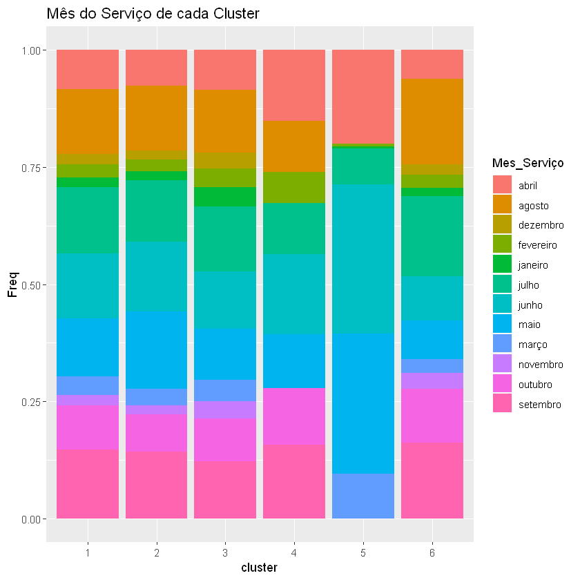

```r
Tabela <- as.data.frame(table(Mes_Serviço=Cluster_Analitics$arrival_month_name, cluster=Cluster_Analitics$cluster))
Tabela[Tabela$Freq > 10,] %>%
    ggplot(aes(fill=Mes_Serviço, y=Freq, x=cluster)) +
    geom_bar(position="fill", stat="identity")+
labs(title="Mês do Serviço de cada Cluster")
```

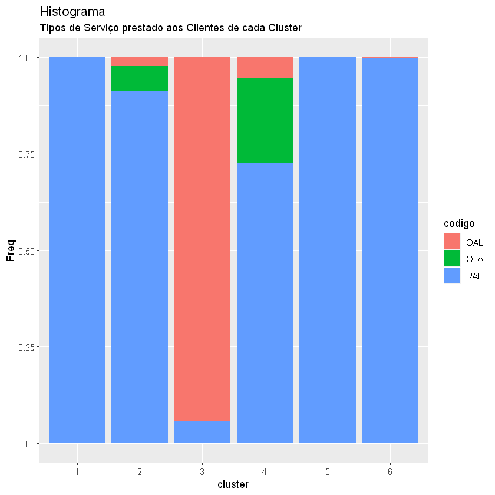

```r
Tabela <- as.data.frame(table(codigo=Cluster_Analitics$codigo, cluster=Cluster_Analitics$cluster))
ggplot(Tabela, aes(fill=codigo, y=Freq, x=cluster)) +
    geom_bar(position="fill", stat="identity")+
labs(title="Histograma", subtitle="Tipos de Serviço prestado aos Clientes de cada Cluster")
```

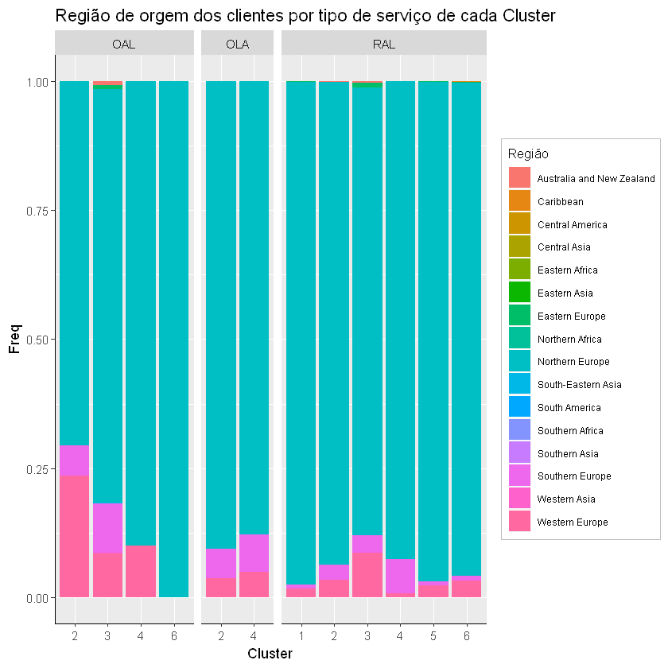

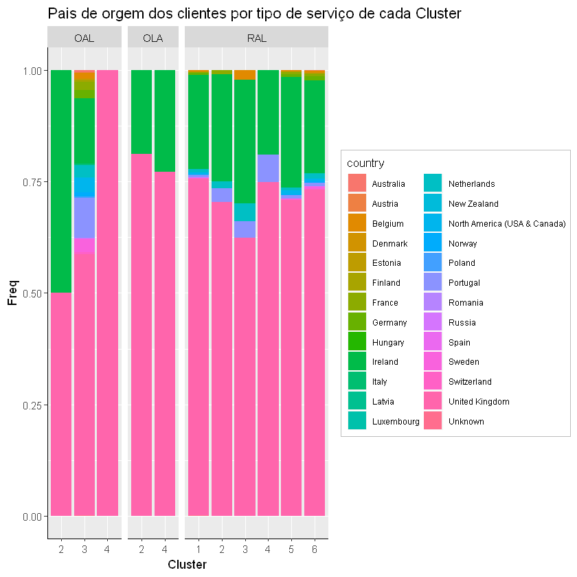

```r
Tabela <- as.data.frame(table(codigo=Cluster_Analitics$codigo, Região=Cluster_Analitics$Region, cluster=Cluster_Analitics$cluster))

Tabela[Tabela$Freq > 0,] %>%
    ggplot(aes(x = cluster,y = Freq, fill = Região)) +
geom_bar(position="fill", stat="identity")+
labs(title ="Região de orgem dos clientes por tipo de serviço de cada Cluster", x = "Cluster") +
theme(panel.border=element_blank(), axis.line = element_line(),legend.background = element_rect(colour='grey'), legend.title = element_text(size = 10), legend.text = element_text(size = 7))+
#theme(legend.position='hidden')
facet_grid( ~ codigo,  space  = "free", scales = "free", drop = TRUE, shrink = TRUE)

Tabela <- as.data.frame(table(codigo=Cluster_Analitics$codigo, country=Cluster_Analitics$country, cluster=Cluster_Analitics$cluster))

Tabela[Tabela$Freq > 5,] %>%
    ggplot(aes(x = cluster,y = Freq, fill = country)) +
geom_bar(position="fill", stat="identity")+
labs(title ="Pais de orgem dos clientes por tipo de serviço de cada Cluster", x = "Cluster") +
theme(panel.border=element_blank(), axis.line = element_line(),legend.background = element_rect(colour='grey'), legend.title = element_text(size = 10), legend.text = element_text(size = 7))+
#theme(legend.position='hidden')
facet_grid( ~ codigo,  space  = "free", scales = "free", drop = TRUE, shrink = TRUE)
```

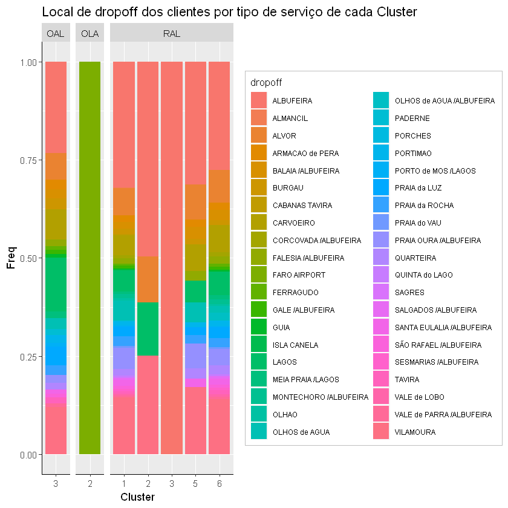

```r
Tabela <- as.data.frame(table(codigo=Cluster_Analitics$codigo, dropoff = Cluster_Analitics$arrival_dropoff, cluster=Cluster_Analitics$cluster))

Tabela[Tabela$Freq > 45,] %>%
    ggplot(aes(x = cluster,
               y = Freq,
               fill = dropoff)) +
geom_bar(position="fill", stat="identity")+
labs(title ="Local de dropoff dos clientes por tipo de serviço de cada Cluster", x = "Cluster") +
theme(panel.border=element_blank(), axis.line = element_line(),legend.background = element_rect(colour='grey'), legend.title = element_text(size = 10), legend.text = element_text(size = 7))+
#theme(legend.position='hidden')
facet_grid( ~ codigo,  space  = "free", scales = "free", drop = TRUE, shrink = TRUE)
```

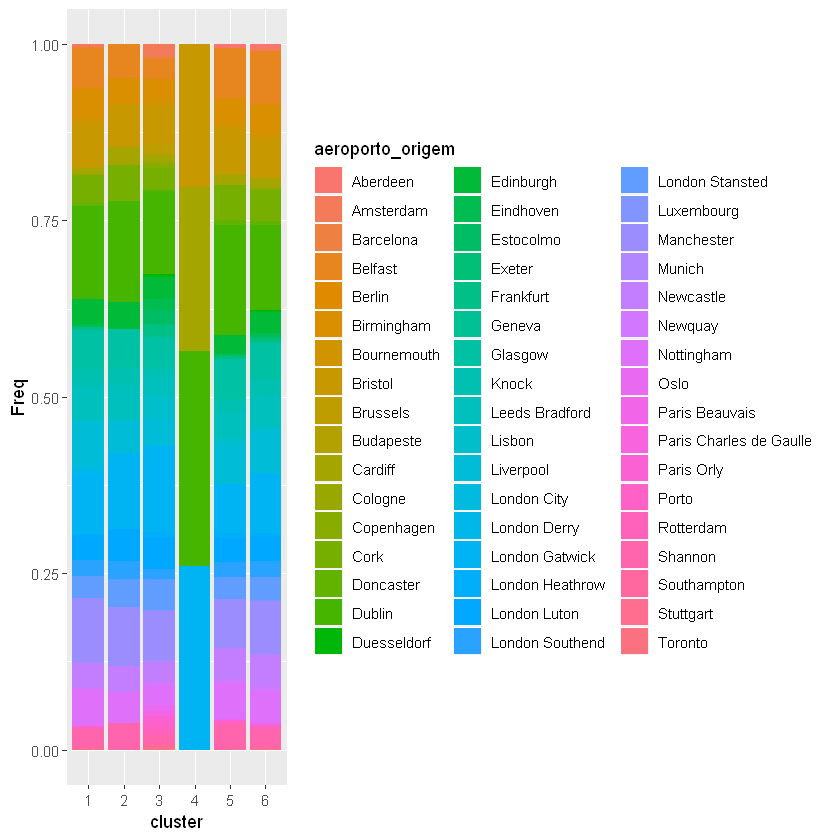

```r
Tabela <- as.data.frame(table(aeroporto_origem = Cluster_Analitics$aeroporto_origem, cluster=Cluster_Analitics$cluster))

Tabela[Tabela$Freq > 10,] %>%
    #top_n(200, Freq) %>%
    ggplot(aes(fill=aeroporto_origem, y=Freq, x=cluster)) +
    geom_bar(position="fill", stat="identity")
```

[figure not shown]

```r
Tabela[Tabela$country == 'Unknown',]<-NULL
```

```
Error in x[...] <- m: replacement has length zero
Traceback:

1. `[<-`(`*tmp*`, Tabela$country == "Unknown", , value = NULL)
2. `[<-.data.frame`(`*tmp*`, Tabela$country == "Unknown", , value = NULL)
3. `[<-`(`*tmp*`, iseq, value = NULL)
4. `[<-.factor`(`*tmp*`, iseq, value = NULL)
```

```r
head(Tabela)
```

A data.frame: 6 × 4

[output not shown]

```r
Tabela[Tabela$Freq > 1 & Tabela$cluster==3 & Tabela$codigo=='RAL',]
```

A data.frame: 29 × 4

|  | codigo <fct> | dropoff <fct> | cluster <fct> | Freq <int> |
| --- | --- | --- | --- | --- |
| 591 | RAL | ALBUFEIRA | 3 | 104 |
| 615 | RAL | ALVOR | 3 | 42 |
| 618 | RAL | ARMACAO de PERA | 3 | 9 |
| 627 | RAL | BALAIA /ALBUFEIRA | 3 | 10 |
| 648 | RAL | BURGAU | 3 | 9 |
| 657 | RAL | CARVOEIRO | 3 | 22 |
| 663 | RAL | CORCOVADA /ALBUFEIRA | 3 | 2 |
| 672 | RAL | FALESIA /ALBUFEIRA | 3 | 3 |
| 714 | RAL | LAGOS | 3 | 33 |
| 726 | RAL | MEIA PRAIA /LAGOS | 3 | 4 |
| 735 | RAL | MONCARAPACHO | 3 | 3 |
| 750 | RAL | OLHAO | 3 | 5 |
| 753 | RAL | OLHOS de AGUA | 3 | 7 |
| 756 | RAL | OLHOS de AGUA /ALBUFEIRA | 3 | 4 |
| 759 | RAL | PADERNE | 3 | 4 |
| 765 | RAL | PERA | 3 | 2 |
| 771 | RAL | PORTIMAO | 3 | 7 |
| 780 | RAL | PRAIA da LUZ | 3 | 8 |
| 783 | RAL | PRAIA da ROCHA | 3 | 12 |
| 786 | RAL | PRAIA do VAU | 3 | 2 |
| 792 | RAL | PRAIA OURA /ALBUFEIRA | 3 | 11 |
| 795 | RAL | QUARTEIRA | 3 | 6 |
| 798 | RAL | QUINTA do LAGO | 3 | 4 |
| 807 | RAL | SALGADOS /ALBUFEIRA | 3 | 2 |
| 822 | RAL | SÃO BRAZ de ALPORTEL | 3 | 2 |
| 840 | RAL | SILVES | 3 | 3 |
| 846 | RAL | TAVIRA | 3 | 9 |
| 858 | RAL | VALE de LOBO | 3 | 3 |
| 879 | RAL | VILAMOURA | 3 | 41 |

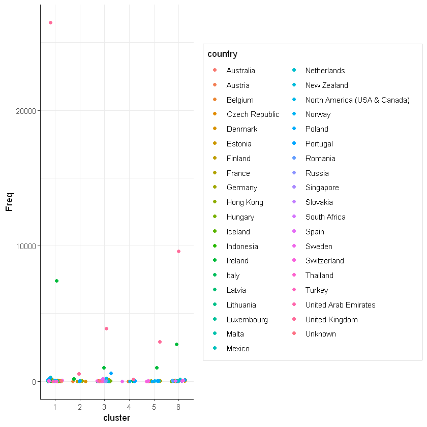

```r
Tabela <- as.data.frame(table(cluster=Cluster_Analitics$cluster, country=Cluster_Analitics$country))
p <- ggplot(Tabela[Tabela$Freq > 1,], aes(x=cluster, y=Freq, colour=country)) +
geom_point(position=position_jitter(width=0.3)) +
#geom_bar(position="stack", stat="identity")
theme_bw() + theme(panel.border=element_blank(), axis.line = element_line(),legend.background = element_rect(colour='grey'))
p
```

```r
countries_sorted%>%
  group_by(cluster) %>%
  top_n(-10) %>%
  ungroup() %>%
  mutate(year=as.factor(year),
         country=reorder_within(country,-lifeExp, year)) %>%
  ggplot(aes(x=country,y=lifeExp, fill=year)) +
  geom_col(show.legend = FALSE) +
  facet_wrap(~year, scales="free_y")+
  coord_flip()+
  scale_x_reordered() +
  scale_y_continuous(expand = c(0,0))
```

[output not shown]

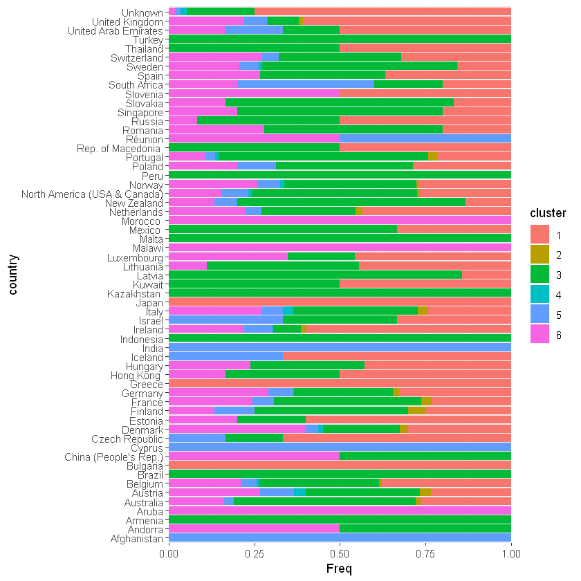

```r
Tabela <- as.data.frame(table(cluster=Cluster_Analitics$cluster, country=Cluster_Analitics$country))
Tabela[Tabela$Freq>0,]%>%
  #group_by(cluster) %>%
  #top_n(15) %>%
  #ungroup() %>%
  #mutate(cluster=as.factor(cluster),
  #       country=reorder_within(country,-Freq, cluster))%>%
ggplot(aes(x=country,y=Freq, fill=cluster)) +
  #geom_col(show.legend = FALSE) +
  geom_bar(position="fill", stat="identity")+
  #facet_wrap(~cluster, nrow = 1, ncol = 6,scales="free_x", shrink = TRUE)+
  coord_flip()+
  #scale_x_reordered() +
  scale_y_continuous(expand = c(0,0))
```

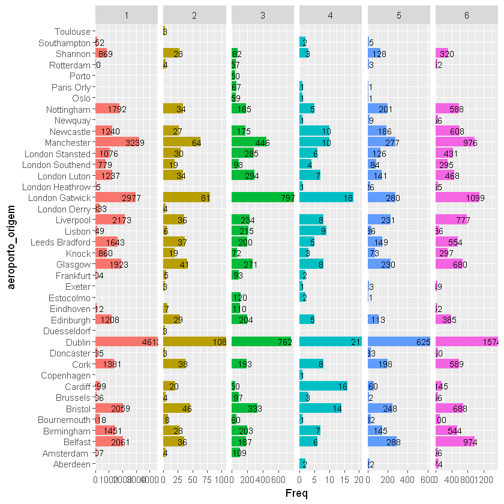

```r
Tabela <- as.data.frame(table(aeroporto_origem = Cluster_Analitics$aeroporto_origem, cluster=Cluster_Analitics$cluster))
Tabela[Tabela$Freq>0,]%>%
  group_by(cluster) %>%
  top_n(30) %>%
  ungroup() %>%
  #mutate(cluster=as.factor(cluster),
  #       aeroporto_origem=reorder_within(aeroporto_origem,-Freq, cluster))%>%
ggplot(aes(x=aeroporto_origem,y=Freq, fill=cluster)) +
  geom_col(show.legend = FALSE) +
  geom_text(aes(label = Freq), size = 3, position = position_stack(vjust = 0.9))+
  facet_wrap(~cluster, nrow = 1, ncol = 6,scales="free_x", shrink = TRUE)+
  coord_flip()+
  scale_x_reordered() +
  scale_y_continuous(expand = c(0,0))
```

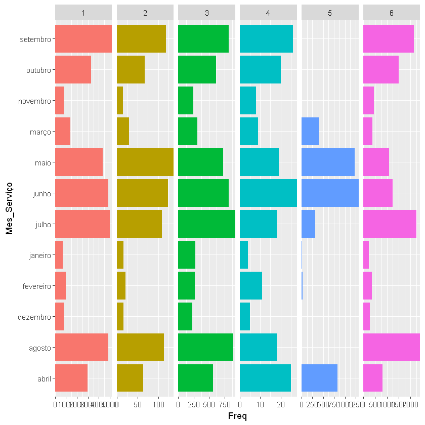

```r
Tabela <- as.data.frame(table(Mes_Serviço=Cluster_Analitics$arrival_month_name, cluster=Cluster_Analitics$cluster))
Tabela[Tabela$Freq>0,]%>%
  group_by(cluster) %>%
  top_n(30) %>%
  ungroup() %>%
  #mutate(cluster=as.factor(cluster),
  #       Mes_Serviço=reorder_within(Mes_Serviço,-Freq, cluster))%>%
ggplot(aes(x=Mes_Serviço,y=Freq, fill=cluster)) +
  geom_col(show.legend = FALSE) +
  facet_wrap(~cluster, nrow = 1, ncol = 6,scales="free_x", shrink = TRUE)+
  coord_flip()+
  scale_x_reordered() +
  scale_y_continuous(expand = c(0,0))
```

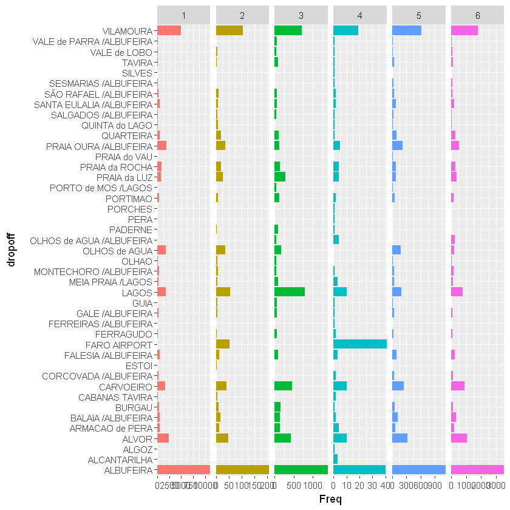

```r
Tabela <- as.data.frame(table(dropoff = Cluster_Analitics$arrival_dropoff, cluster=Cluster_Analitics$cluster))
Tabela[Tabela$Freq>0,]%>%
  group_by(cluster) %>%
  top_n(30) %>%
  ungroup() %>%
  #mutate(cluster=as.factor(cluster),dropoff=reorder_within(dropoff,-Freq, cluster))%>%
ggplot(aes(x=dropoff,y=Freq, fill=cluster)) +
  geom_col(show.legend = FALSE) +
  facet_wrap(~cluster, nrow = 1, ncol = 6,scales="free_x", shrink = TRUE)+
  coord_flip()+
  scale_x_reordered() +
  scale_y_continuous(expand = c(0,0))
```

```r
clusters.country <- sqlQuery(conn, "select country,
sum(cluster_1) cluster_1,
sum(cluster_2) cluster_2,
sum(cluster_3) cluster_3,
sum(cluster_4) cluster_4,
sum(cluster_5) cluster_5,
sum(cluster_6) cluster_6
from(
select b.country,
case when cluster=1 then count(b.country) else 0 end as cluster_1,
case when cluster=2 then count(b.country) else 0 end as cluster_2,
case when cluster=3 then count(b.country) else 0 end as cluster_3,
case when cluster=4 then count(b.country) else 0 end as cluster_4,
case when cluster=5 then count(b.country) else 0 end as cluster_5,
case when cluster=6 then count(b.country) else 0 end as cluster_6
from feedback_cluster a
inner join FeatureEngineering b on a.book_id=b.book_id
group by b.country, cluster
)T
group by country
order by cluster_1,cluster_2,cluster_3,cluster_4,cluster_5,cluster_6
")
```

```r
str(clusters.country)
```

```
'data.frame':	73 obs. of  7 variables:
 $ country  : Factor w/ 72 levels "Afghanistan",..: 40 43 1 55 53 68 72 14 36 5 ...
 $ cluster_1: int  0 0 0 0 0 0 0 0 0 0 ...
 $ cluster_2: int  0 0 0 0 0 0 0 0 0 0 ...
 $ cluster_3: int  0 0 0 0 0 0 0 0 0 0 ...
 $ cluster_4: int  0 0 0 0 1 1 1 1 1 1 ...
 $ cluster_5: int  0 0 1 1 0 0 0 0 0 0 ...
 $ cluster_6: int  1 1 0 1 0 0 0 0 0 1 ...
```

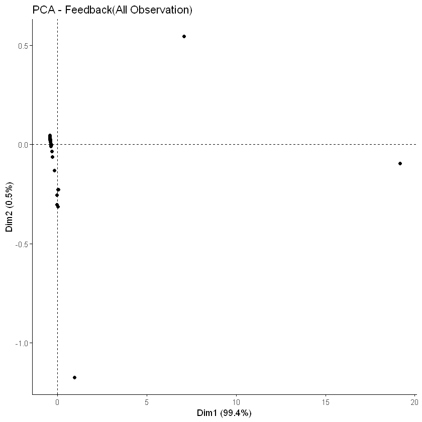

```r
#Metodo Visual
pca <- prcomp(scale(clusters.country[, 2:7]), scores=TRUE, cor=TRUE)
#fviz_pca_ind(pca, habillage=clusters.country[, 1], title = "PCA - Feedback(All Observation)", geom = "point", ggtheme = theme_classic())
fviz_pca_ind(pca, repel = TRUE, title = "PCA - Feedback(All Observation)", geom = "point", ggtheme = theme_classic())
```

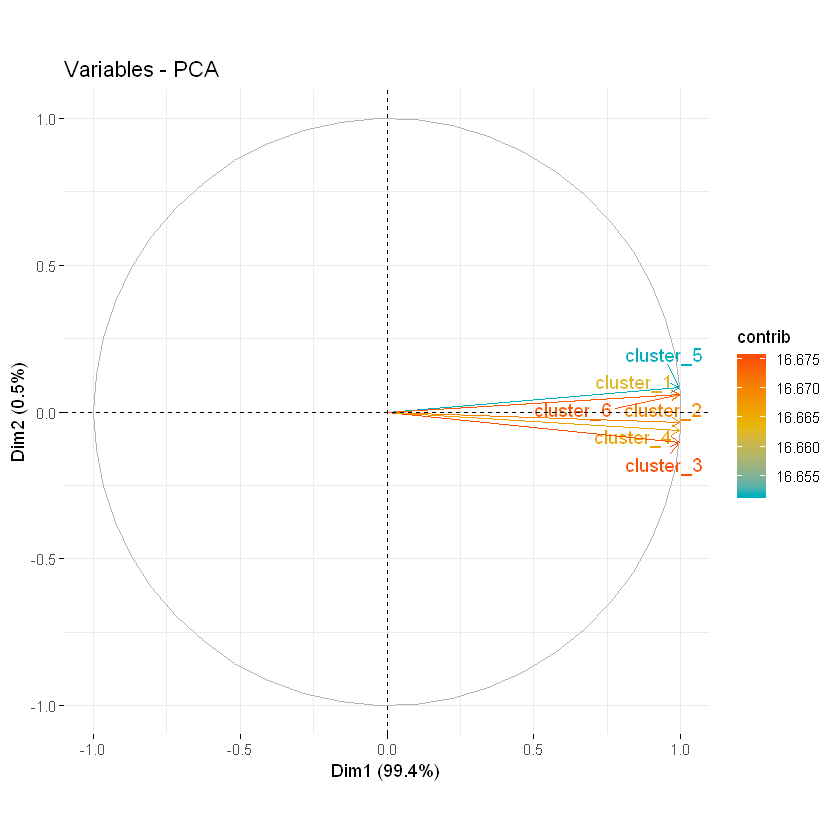

```r
fviz_pca_var(pca, col.var = 'contrib',
            gradient.cols = c('#00AFBB', '#E7B800', '#FC4E07'),
            repel = TRUE)
```

```r
clusters.country <- sqlQuery(conn, "select
cluster,
sum(ISNULL(Afghanistan,0))Afghanistan,
sum(ISNULL(Andorra,0))Andorra,
sum(ISNULL(Armenia,0))Armenia,
sum(ISNULL(Aruba,0))Aruba,
sum(ISNULL(Australia,0))Australia,
sum(ISNULL(Austria,0))Austria,
sum(ISNULL(Belgium,0))Belgium,
sum(ISNULL(Brazil,0))Brazil,
sum(ISNULL(Bulgaria,0))Bulgaria,
sum(ISNULL(China,0))China,
sum(ISNULL(Cyprus,0))Cyprus,
sum(ISNULL(Czech_Republic,0))Czech_Republic,
sum(ISNULL(Denmark,0))Denmark,
sum(ISNULL(Estonia,0))Estonia,
sum(ISNULL(Finland,0))Finland,
sum(ISNULL(France,0))France,
sum(ISNULL(Germany,0))Germany,
sum(ISNULL(Greece,0))Greece,
sum(ISNULL(Hong_Kong,0))Hong_Kong,
sum(ISNULL(Hungary,0))Hungary,
sum(ISNULL(Iceland,0))Iceland,
sum(ISNULL(India,0))India,
sum(ISNULL(Indonesia,0))Indonesia,
sum(ISNULL(Ireland,0))Ireland,
sum(ISNULL(Israel,0))Israel,
sum(ISNULL(Italy,0))Italy,
sum(ISNULL(Japan,0))Japan,
sum(ISNULL(Kazakhstan,0))Kazakhstan,
sum(ISNULL(Kuwait,0))Kuwait,
sum(ISNULL(Latvia,0))Latvia,
sum(ISNULL(Lithuania,0))Lithuania,
sum(ISNULL(Luxembourg,0))Luxembourg,
sum(ISNULL(Malawi,0))Malawi,
sum(ISNULL(Malta,0))Malta,
sum(ISNULL(Mexico,0))Mexico,
sum(ISNULL(Morocco,0))Morocco,
sum(ISNULL(Netherlands,0))Netherlands,
sum(ISNULL(New_Zealand,0))New_Zealand,
sum(ISNULL(USA_Canada,0))USA_Canada,
sum(ISNULL(Norway,0))Norway,
sum(ISNULL(Peru,0))Peru,
sum(ISNULL(Poland,0))Poland,
sum(ISNULL(Portugal,0))Portugal,
sum(ISNULL(Macedonia,0))Macedonia,
sum(ISNULL(Reunion,0))Reunion,
sum(ISNULL(Romania,0))Romania,
sum(ISNULL(Russia,0))Russia,
sum(ISNULL(Singapore,0))Singapore,
sum(ISNULL(Slovakia,0))Slovakia,
sum(ISNULL(Slovenia,0))Slovenia,
sum(ISNULL(South_Africa,0))South_Africa,
sum(ISNULL(Spain,0))Spain,
sum(ISNULL(Sweden,0))Sweden,
sum(ISNULL(Switzerland,0))Switzerland,
sum(ISNULL(Thailand,0))Thailand,
sum(ISNULL(Turkey,0))Turkey,
sum(ISNULL(United_Arab_Emirates,0))United_Arab_Emirates,
sum(ISNULL(United_Kingdom,0))United_Kingdom,
sum(ISNULL(Unknown,0))Unknown
from(
select
cluster,
case when  b.country = 'Afghanistan' then count(b.country) end as Afghanistan,
case when  b.country = 'Andorra' then count(b.country) end as Andorra,
case when  b.country = 'Armenia' then count(b.country) end as Armenia,
case when  b.country = 'Aruba' then count(b.country) end as Aruba,
case when  b.country = 'Australia' then count(b.country) end as Australia,
case when  b.country = 'Austria' then count(b.country) end as Austria,
case when  b.country = 'Belgium' then count(b.country) end as Belgium,
case when  b.country = 'Brazil' then count(b.country) end as Brazil,
case when  b.country = 'Bulgaria' then count(b.country) end as Bulgaria,
case when  b.country = 'China (People''s Rep.)' then count(b.country) end as China,
case when  b.country = 'Cyprus' then count(b.country) end as Cyprus,
case when  b.country = 'Czech Republic' then count(b.country) end as Czech_Republic,
case when  b.country = 'Denmark' then count(b.country) end as Denmark,
case when  b.country = 'Estonia' then count(b.country) end as Estonia,
case when  b.country = 'Finland' then count(b.country) end as Finland,
case when  b.country = 'France' then count(b.country) end as France,
case when  b.country = 'Germany' then count(b.country) end as Germany,
case when  b.country = 'Greece' then count(b.country) end as Greece,
case when  b.country = 'Hong Kong' then count(b.country) end as Hong_Kong,
case when  b.country = 'Hungary' then count(b.country) end as Hungary,
case when  b.country = 'Iceland' then count(b.country) end as Iceland,
case when  b.country = 'India' then count(b.country) end as India,
case when  b.country = 'Indonesia' then count(b.country) end as Indonesia,
case when  b.country = 'Ireland' then count(b.country) end as Ireland,
case when  b.country = 'Israel' then count(b.country) end as Israel,
case when  b.country = 'Italy' then count(b.country) end as Italy,
case when  b.country = 'Japan' then count(b.country) end as Japan,
case when  b.country = 'Kazakhstan' then count(b.country) end as Kazakhstan,
case when  b.country = 'Kuwait' then count(b.country) end as Kuwait,
case when  b.country = 'Latvia' then count(b.country) end as Latvia,
case when  b.country = 'Lithuania' then count(b.country) end as Lithuania,
case when  b.country = 'Luxembourg' then count(b.country) end as Luxembourg,
case when  b.country = 'Malawi' then count(b.country) end as Malawi,
case when  b.country = 'Malta' then count(b.country) end as Malta,
case when  b.country = 'Mexico' then count(b.country) end as Mexico,
case when  b.country = 'Morocco' then count(b.country) end as  Morocco,
case when  b.country = 'Netherlands' then count(b.country) end as Netherlands,
case when  b.country = 'New Zealand' then count(b.country) end as New_Zealand,
case when  b.country = 'North America (USA & Canada)' then count(b.country) end as USA_Canada,
case when  b.country = 'Norway' then count(b.country) end as Norway,
case when  b.country = 'Peru' then count(b.country) end as Peru,
case when  b.country = 'Poland' then count(b.country) end as Poland,
case when  b.country = 'Portugal' then count(b.country) end as Portugal,
case when  b.country = 'Rep. of Macedonia' then count(b.country) end as Macedonia,
case when  b.country = 'Réunion' then count(b.country) end as Reunion,
case when  b.country = 'Romania' then count(b.country) end as Romania,
case when  b.country = 'Russia' then count(b.country) end as Russia,
case when  b.country = 'Singapore' then count(b.country) end as Singapore,
case when  b.country = 'Slovakia' then count(b.country) end as Slovakia,
case when  b.country = 'Slovenia' then count(b.country) end as Slovenia,
case when  b.country = 'South Africa' then count(b.country) end as South_Africa,
case when  b.country = 'Spain' then count(b.country) end as Spain,
case when  b.country = 'Sweden' then count(b.country) end as Sweden,
case when  b.country = 'Switzerland' then count(b.country) end as Switzerland,
case when  b.country = 'Thailand' then count(b.country) end as Thailand,
case when  b.country = 'Turkey' then count(b.country) end as Turkey,
case when  b.country = 'United Arab Emirates' then count(b.country) end as United_Arab_Emirates,
case when  b.country = 'United Kingdom' then count(b.country) end as United_Kingdom,
case when  b.country = 'Unknown' then count(b.country) end as Unknown
from feedback_cluster a
inner join FeatureEngineering b on a.book_id=b.book_id
--where aeroporto_origem is not null
group by b.country, cluster
)T
group by cluster
")
str(clusters.country)
```

```
'data.frame':	6 obs. of  60 variables:
 $ cluster             : int  1 2 3 4 5 6
 $ Afghanistan         : int  0 0 0 0 1 0
 $ Andorra             : int  0 0 1 2 0 1
 $ Armenia             : int  0 0 1 0 0 0
 $ Aruba               : int  0 0 0 1 0 1
 $ Australia           : int  20 9 40 9 2 12
 $ Austria             : int  13 8 17 12 3 12
 $ Belgium             : int  97 61 93 65 13 58
 $ Brazil              : int  0 0 1 1 0 0
 $ Bulgaria            : int  1 1 0 1 0 0
 $ China               : int  1 0 1 0 0 1
 $ Cyprus              : int  0 0 1 0 1 0
 $ Czech_Republic      : int  4 3 3 0 1 3
 $ Denmark             : int  47 19 25 22 3 38
```

[output cut: 46 more lines]

```r
#Metodo Visual
pca <- prcomp(scale(clusters.country[, 2:60]), scores=TRUE, cor=TRUE)
#fviz_pca_ind(pca, habillage=clusters.country[, 1], title = "PCA - Feedback(All Observation)", geom = "point", ggtheme = theme_classic())
#fviz_pca_var(pca, col.var = as.factor(clusters.country$cluster),
#            palette = c("#0073C2FF", "#EFC000FF", "#868686FF", "#123456FF", "#987654FF","#654784FF"),
#            legend.title = "Cluster",
#            repel = TRUE)
```

[output not shown]

```r
#fviz_pca_var(pca, col.var = 'contrib',
#            gradient.cols = c('#00AFBB', '#E7B800', '#FC4E07'),
#            repel = TRUE)

fviz_pca_var(pca, col.var = clusters.country[, 1],
            #palette = c("#0073C2FF", "#EFC000FF", "#868686FF", "#123456FF", "#987654FF","#654784FF"),
            legend.title = "Cluster",
            repel = TRUE)
```

[output not shown]

[figure not shown]

```r
#fviz_screeplot(pca, ncp = 60)
fviz_pca_ind(pca, col.var = 'contrib', repel = TRUE, tle = "PCA - Feedback",ggtheme = theme_classic())
```

```r
length(clusters.country[, 1])
```

6

```r
as.factor(clusters.country$cluster)
```

1. 1

2. 2

3. 3

4. 4

5. 5

6. 6

**Levels**:**

1. '1'

2. '2'

3. '3'

4. '4'

5. '5'

6. '6'

```r
head(feedback_cluster)
```

```
Error in head(feedback_cluster): object 'feedback_cluster' not found
Traceback:

1. head(feedback_cluster)
```

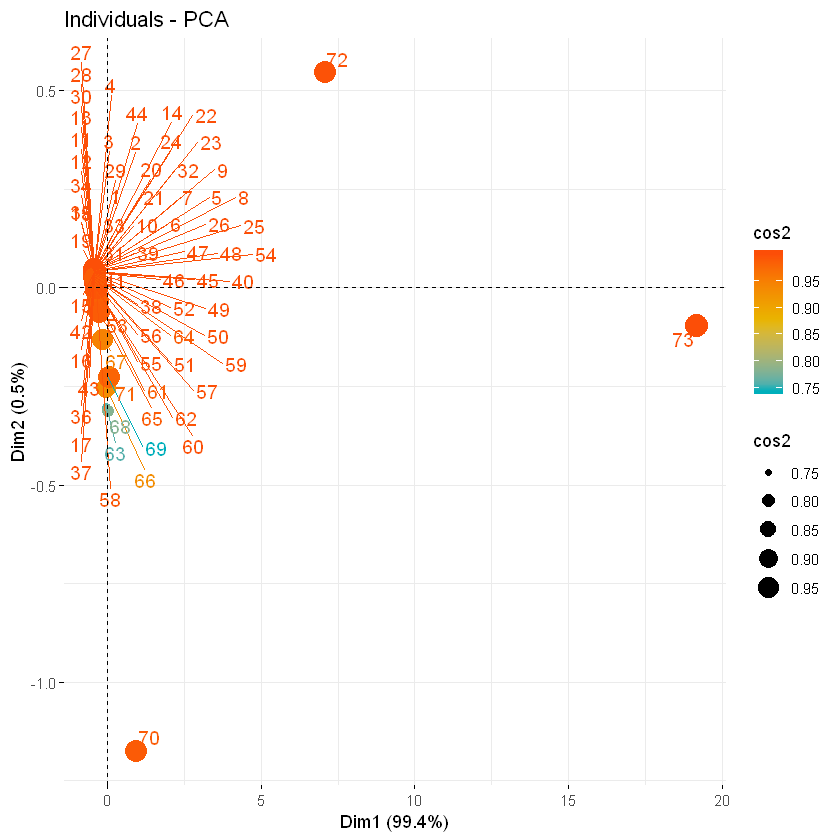

```r
fviz_pca_ind(pca, col.ind = "cos2", pointsize = "cos2",
             gradient.cols = c("#00AFBB", "#E7B800", "#FC4E07"),
             repel = TRUE
)
```